# R Notebook

Philip Stauffer and Darren Tyson

2024-02-23

## Copied from 20240102_analysis_PES_ridges.Rmd

# ATP stim: 20240102_ATPstim_3dayPLX_longstim – FBS free media in the assay

First pass visualizing the results of the experiment (details can be found on elab). See `~/Melanoma/Ca2Mobilization/20240102_ATPstim_3dayPLX` directory for thunor .tsv platemap and for barcode information.

pERK staining procedure and imaging details can be found in the elab entry titled 20231116_ATPstim

## Data processing details

MetaExpress multiwavelength cell scoring analysis performed with the settings saved in: “VQU_PES_Ca2+ mobilization”

```r
library(tidyr)
library(ggplot2)
library(ggridges)
library(dplyr)
library(viridis)
```

### Function to quantify ppERK using both proportion of positive cells and the avg intensity

Using both proportion of cells staining positively for ppERK and the integrated values of the positive cells.

```r
ppERKint <- function(dat, signif=4) {
    cell_count <- nrow(dat)
    pos_cells <- nrow(dat[dat$positive.w2==1,])
    val <- pos_cells/cell_count*sum(dat[dat$positive.w2==1,]$avg.pERK)
    val <- signif(val,signif)
    return(val)
}
```

## Load data

```r
fn <- "https://www.dropbox.com/scl/fi/xgjbo711hr5mru5axfhh3/20240102_singlecell_all_ATP.csv?rlkey=fzbzg5h0g25ponw1igw5kizdu&dl=1"
d <- read.csv(fn)
```

# QC

Removing cells with total area > 4500 and < 100 $pixels^2$  
Removing objects with integrated intensity > 5e6 because they tend to be bubbles, precipitated antibody, or debris. It was found that setting minimum area to above 200 pixels^2 predominantly filtered out data from the Ca2+ free control group. Because of this bias in filtering, minimum area was set to > 100 pixels.

### Filtering (QC)

NOTE: DRT increased filter for total.area to 100 pixels^2

```r
o_nrow <- nrow(d)
d <- d[d$total.area < 4500 & d$total.area > 100 & d$w2.stain.integr.intens <5e6,]
message(cat("Current nrow = ",nrow(d),"\nOriginal nrow = ",o_nrow))
```

```
Current nrow =  1912686
Original nrow =  2162412
```

```r
message(cat("QC removed",signif(100-(nrow(d)/o_nrow*100),2),"% of cells"))
```

```
QC removed 12 % of cells
```

### Annotation

```r
d$drug1[d$drug1== ""] <- "abctrl"
ab_ctrl_wells <- unique(d[d$drug1=="abctrl",]$well)
untx_ctrl_wells <- unique(d[d$drug1=="control",]$well)
ctrl_wells <- c(ab_ctrl_wells,untx_ctrl_wells)

d[is.na(d$drug1.conc),"drug1.conc"] <- -1


tx <- tibble(d[!d$well %in% ctrl_wells, ])
tx <- tx[order(tx$BRAFi.tx.time),]

rownames(tx) <- NULL

ctrls <- d[d$well %in% ctrl_wells, ]

tx$drug1.conc <- signif(tx$drug1.conc, digits= 2)
tx$drug2[tx$drug1== "persistent"] <- 0
```

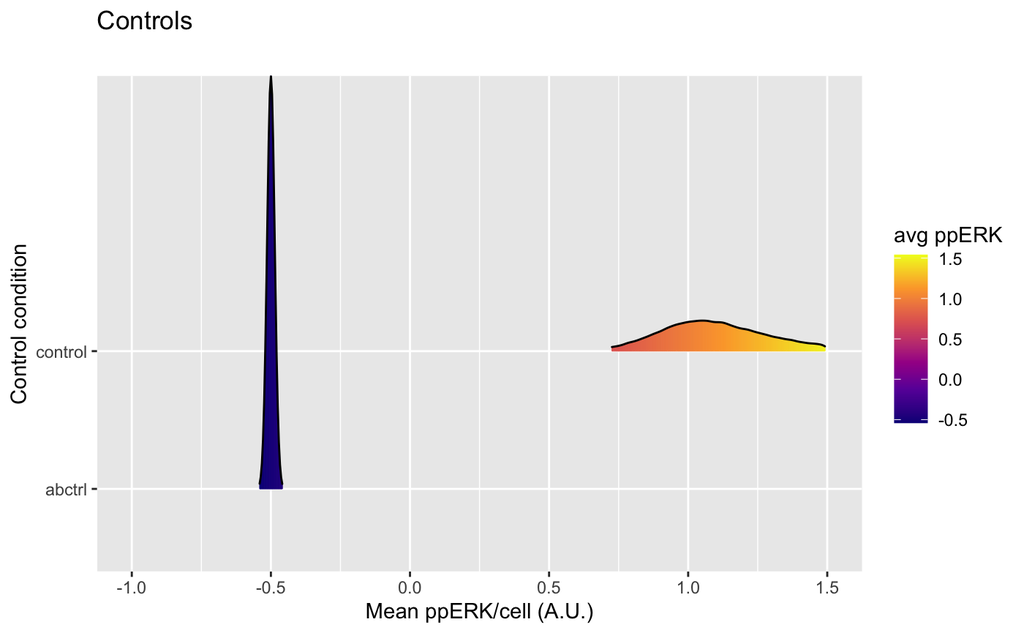

```r
ggplot(d[d$well %in% ctrl_wells, ], aes(x = avg.pERK, y = drug1, fill = after_stat(x))) +
    xlim(-1,1.5) +
    geom_density_ridges_gradient(scale = 3, rel_min_height = 0.01) +
    scale_fill_viridis_c(name = "avg ppERK", option = "C") +
    labs(title = 'Controls',
         subtitle="") +
    xlab("Mean ppERK/cell (A.U.)") + ylab("Control condition")
```

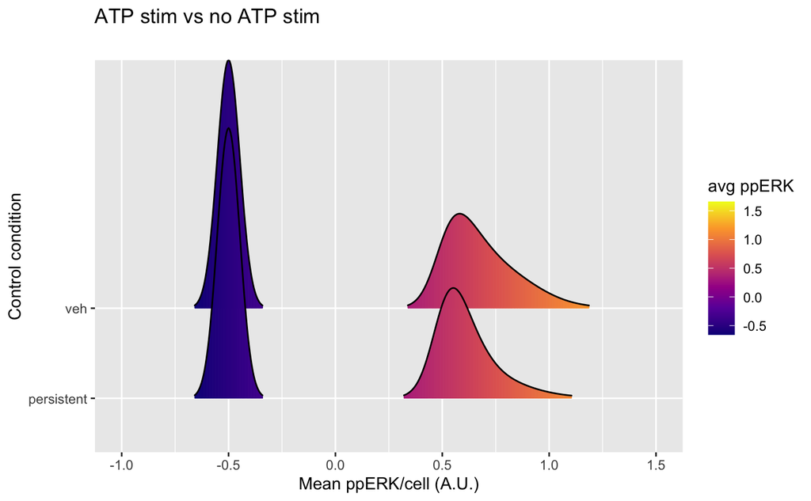

```r
ggplot(tx[tx$drug1 %in% c("persistent", "veh"),], aes(x = avg.pERK, y = drug1, fill = after_stat(x))) +
    xlim(-1,1.5) +
    geom_density_ridges_gradient(scale = 3, rel_min_height = 0.01) +
    scale_fill_viridis_c(name = "avg ppERK", option = "C") +
    labs(title = 'ATP stim vs no ATP stim',
         subtitle="") +
    xlab("Mean ppERK/cell (A.U.)") + ylab("Control condition")
```

### Determine percent positive for each condition using bootstrapping

```r
f <- tx[,c("cell.id", "plate.id", "well", "BRAFi.tx.time", "atp.tx.time", "drug1", "drug1.conc", "total.area", "positive.w2","w2.stain.integr.intens")]

f <- f[f$atp.tx.time %in% c(0,1,30),]
f <- f[order(f$plate.id, f$well),]
rownames(f) <- NULL

f$uid <- paste(f$plate.id, f$well, sep="_")
uids <- unique(f$uid)
f$condition <- paste(f$plate.id, f$well, f$atp.tx.time, f$drug1, f$drug1.conc, sep="_")
conditions <- f[!duplicated(f$uid),]$condition
conditions_plates <- sapply(strsplit(conditions, "_"), "[[", 1)
conditions_atp_time <- sapply(strsplit(conditions, "_"), "[[", 3)

no_ppERK_ids <- f[f$positive.w2==0,]$cell.id
```

### Drugs on each plate

```r
unique(f[f$plate.id=="142708",]$drug1)
```

```
[1] "isoPPADS"   "persistent" "veh"        "aacba"      "azd9056"    "a740003"
```

```r
unique(f[f$plate.id=="142709",]$drug1)
```

```
[1] "bx430"      "persistent" "veh"        "5bdbd"      "gefapixant" "af353"
```

```r
set.seed(13)
n <- 1000

prop_pos <- do.call(c, lapply(uids, function(id) {
    cellids <- f[f$uid==id,]$cell.id
    cid_samples <- lapply(1:10, function(i) sample(cellids, n))
    unlist(lapply(cid_samples, function(cids) length(which(f[f$cell.id %in% cids,]$positive.w2==1))/nrow(f[f$cell.id %in% cids,])))
}))
```

```r
prop_pos_df$cond2 <- gsub("_[A-P][0-2][0-9]_","_",prop_pos_df$condition)
mean_props <- sapply(unique(prop_pos_df$cond2), function(co) mean(prop_pos_df[prop_pos_df$cond2==co,]$prop_pos))

veh_mean_props <- mean_props[grep("veh", names(mean_props))]
veh_mean_prop_range <- sapply(142708:142709, function(x)
    veh_mean_props[grep(x,names(veh_mean_props))][1] -
      veh_mean_props[grep(x,names(veh_mean_props))][2])

b <- prop_pos_df[(grepl("_30_",prop_pos_df$condition) &
                    grepl(9.8e-08, prop_pos_df$condition)) | grepl("veh", prop_pos_df$condition),]
b$drug1 <- sapply(strsplit(b$condition, "_"), "[[", 4)
b$drug1.conc <- as.numeric(sapply(strsplit(b$condition, "_"), "[[", 5))
drugs <- unique(b$drug1)

b$prop_pos_diff <- b$prop_pos - mean_props[gsub("_30_","_1_",b$cond2)]
b$prop_pos_ratio <- ifelse(grepl("142708",b$uid), b$prop_pos_diff/veh_mean_prop_range[1], b$prop_pos_diff/veh_mean_prop_range[2])
```

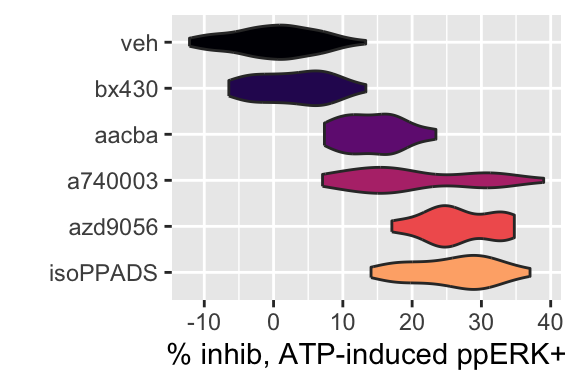

```r
dtp <- subset(b, !grepl("_1_", condition) & drug1 %in% c("a740003","aacba","azd9056","isoPPADS", "bx430", "veh"))
dtp$drug1 <- factor(dtp$drug1, levels=c("isoPPADS","azd9056","a740003","aacba", "bx430", "veh"))
mycolors <- viridis::magma(7, direction=-1)[-1]

ggplot(data=dtp, aes(x= factor(drug1), y= 100 * (1 - prop_pos_ratio), fill=factor(drug1))) +
  # geom_boxplot() +
  geom_violin() +
  coord_flip() +
  scale_fill_manual(values=mycolors) +  # , guide = guide_legend(reverse = TRUE)
  xlab("") +
  ylab("% inhib, ATP-induced ppERK+") +
  theme(legend.position = "none")
```

```r
ggsave("~/Desktop/P2Xi_ATP_dose-dependent_ppERK_drug-tol.pdf", width=3, height=2, units="in", device="pdf")
```

```r
m <- lm(prop_pos_ratio ~ drug1, data=dtp)
m_anova <- aov(m)
m_tukey <- TukeyHSD(m_anova)
m_tukey$drug1[grep("veh",rownames(m_tukey$drug1)),]
```

```
                   diff         lwr        upr        p adj
veh-isoPPADS 0.25727600  0.21768251 0.29686950 0.000000e+00
veh-azd9056  0.26756353  0.22797003 0.30715703 0.000000e+00
veh-a740003  0.19898004  0.15938654 0.23857354 0.000000e+00
veh-aacba    0.14235470  0.10276120 0.18194820 1.243450e-14
veh-bx430    0.02705711 -0.01253639 0.06665061 3.655243e-01
```